# Ajuste de MLG

Taciane de Souza

2024-06-25

# Apresentação do problema

Temos a seguinte questão retirada do livro do professor Gilberto Paula (https://www.ime.usp.br/~giapaula/texto_2024.pdf) e os dados obtidos em (https://www.ime.usp.br/~giapaula/reg2.txt).

**Questão:** (Paula, 2024) No arquivo reg2.txt são apresentadas as siglas dos 48 estados norte-americanos contíguos juntamente com as seguintes variáveis: taxa (taxa do combustível no estado em USD), licença (proporção de motoristas licenciados), renda (renda per capita em USD), estradas (ajuda federal para as estradas em mil USD) e consumo (consumo de combustível por habitante). O interesse nesse estudo é tentar explicar o consumo médio de combustível segundo as variáveis.

| UF | taxa | licenca | renda | estradas | consumo |
| --- | --- | --- | --- | --- | --- |
| ME | 9.0 | 0.525 | 3571 | 1976 | 541 |
| NH | 9.0 | 0.572 | 4092 | 1250 | 524 |
| VT | 9.0 | 0.580 | 3865 | 1586 | 561 |
| MA | 7.5 | 0.529 | 4870 | 2351 | 414 |
| RI | 8.0 | 0.544 | 4399 | 431 | 410 |
| CT | 10.0 | 0.571 | 5342 | 1333 | 457 |

# Análise descritiva

|  | taxa | licenca | renda | estradas | consumo |
| --- | --- | --- | --- | --- | --- |
|  | Min. : 5.000 | Min. :0.4510 | Min. :3063 | Min. : 431 | Min. :344.0 |
|  | 1st Qu.: 7.000 | 1st Qu.:0.5298 | 1st Qu.:3739 | 1st Qu.: 3110 | 1st Qu.:509.5 |
|  | Median : 7.500 | Median :0.5645 | Median :4298 | Median : 4736 | Median :568.5 |
|  | Mean : 7.668 | Mean :0.5703 | Mean :4242 | Mean : 5565 | Mean :576.8 |
|  | 3rd Qu.: 8.125 | 3rd Qu.:0.5952 | 3rd Qu.:4579 | 3rd Qu.: 7156 | 3rd Qu.:632.8 |
|  | Max. :10.000 | Max. :0.7240 | Max. :5342 | Max. :17782 | Max. :968.0 |

## Histogramas

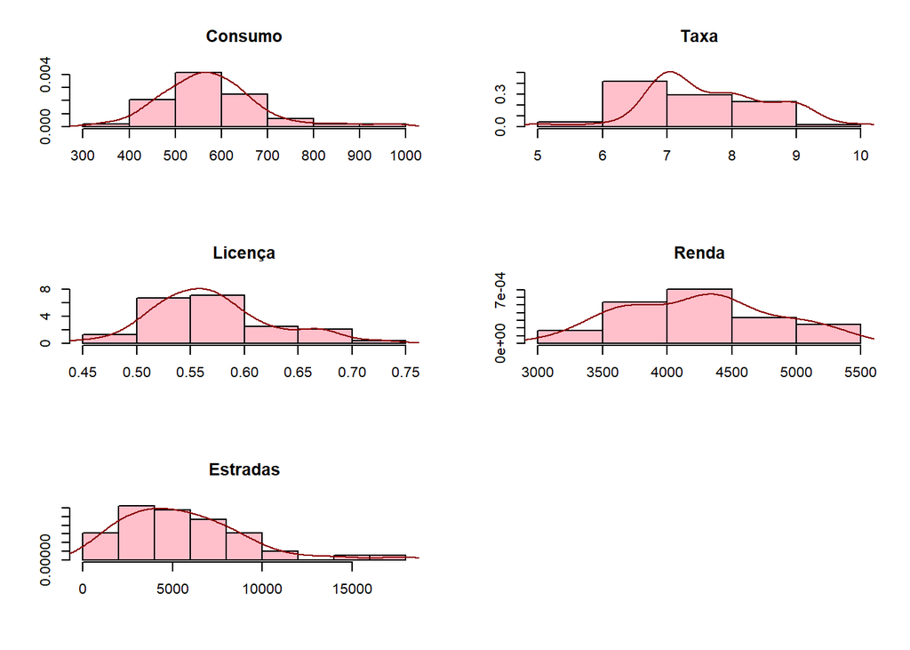

## Boxplots

Os gráficos de boxplots, ou diagrma de caixas, são muito úteis para identificar a existência de outliers no conjunto de dados. Em um gráfico de boxplot são apresentados os limites inferior e superior, 1º quartil, mediana, 3º quartil e possíveis valores discrepantes.

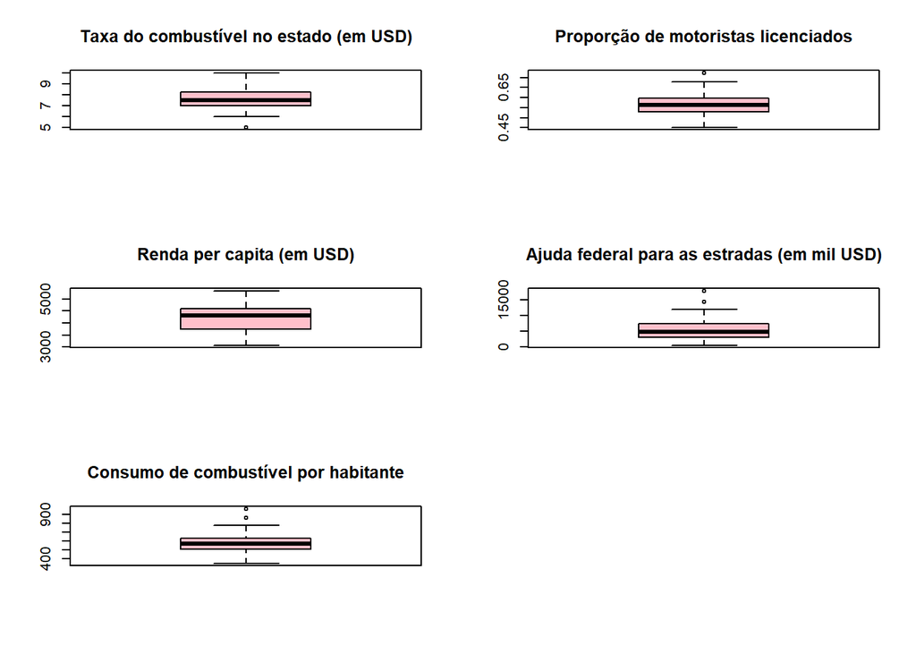

Pelos gráficos acima podemos tirar algumas conclusões sobre as variáveis. Observamos alguns outliers como para a taxa mínima de combustível que é 5 USD no estado do Texas. A proporção máxima de motoristas licenciados é de 0.724 (72,4%) no estado Dakota do Sul. Para a ajuda federal para as estradas observamos dois valores extremos nos estados IL (Illinois) e TX (Texas), e para o consumo de combustível por habitante também é observado dois valores extremos nos estados de WY (Wyoming) e NV (Nevada).

## Diagrama de dispersão

Diagramas de dispersão são úteis para visualizar a relação e a força entre duas variáveis.

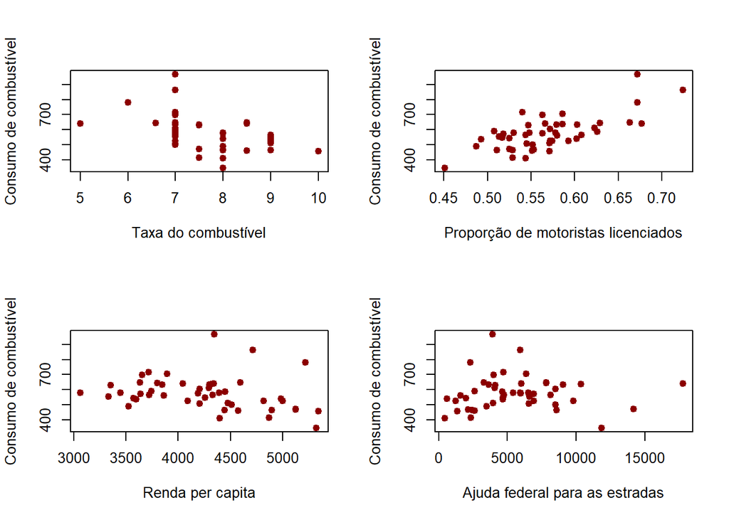

Tabela de correlação entre as variáveis

|  | taxa | licenca | renda | estradas | consumo |
| --- | --- | --- | --- | --- | --- |
| taxa | 1.00 | -0.29 | 0.01 | -0.52 | -0.45 |
| licenca | -0.29 | 1.00 | 0.16 | -0.06 | 0.70 |
| renda | 0.01 | 0.16 | 1.00 | 0.05 | -0.24 |
| estradas | -0.52 | -0.06 | 0.05 | 1.00 | 0.02 |
| consumo | -0.45 | 0.70 | -0.24 | 0.02 | 1.00 |

# Ajuste de MLG

Como o objetivo do estudo é tentar explicar o consumo médio de combustível e, ao verificar o gráfico de histograma das variáveis, identificamos que possuem distribuiçôes assimétricas com caudas mais pesadas. Prtanto a distribuição Gama pode ser uma boa opção para acomodar melhor os outliers.

A variável resposta deste experimento é quantitativa denotada pelo `consumo` médio de combustível. Todas as variáveis regressoras também são quantitativas. A variável `taxa` possui $i$ níveis com $i=1,...48$. A variável `licença` possui $j$ níveis com $j=1,...48$. A variável `renda` possui $k$ níveis com $k=1,...48$. A variável `estradas` possui $l$ níveis com $l=1,...48$.

Iremos ajustar o modelo saturado (com todas as variáveis) que será a nossa hipótese alternativa.

Modelo saturado sob $H_{1}:$

$log(\mu_{ijkl})=\alpha + \beta(taxa)_{ijkl} + \gamma(licença)_{ijkl} + \delta(renda)_{ijkl} + \varepsilon(estradas)_{ijkl}$

Ajuste de modelo gama com função de ligação logarítmica

```
##
## Call:
## glm(formula = consumo ~ taxa + licenca + renda + estradas, family = Gamma(link = "log"))
##
## Coefficients:
##               Estimate Std. Error t value Pr(>|t|)
## (Intercept)  6.078e+00  2.912e-01  20.869  < 2e-16 ***
## taxa        -5.711e-02  2.036e-02  -2.805  0.00752 **
## licenca      2.284e+00  3.018e-01   7.567 1.96e-09 ***
## renda       -1.358e-04  2.703e-05  -5.024 9.35e-06 ***
## estradas    -3.839e-06  5.320e-06  -0.722  0.47445
## ---
## Signif. codes:  0 '***' 0.001 '**' 0.01 '*' 0.05 '.' 0.1 ' ' 1
##
## (Dispersion parameter for Gamma family taken to be 0.01083107)
##
##     Null deviance: 1.66678  on 47  degrees of freedom
## Residual deviance: 0.45462  on 43  degrees of freedom
## AIC: 533.29
##
## Number of Fisher Scoring iterations: 4
```

Observamos que somente a variável `estradas` não foi significativa para o modelo ao nível de 5% de confiança.

## Seleção de modelo

Iremos utilizar a função *stepAIC* do pacote *MASS* para selecionar um modelo restrito para a nossa hipótese nula.

```r
stepAIC(mod.S)
```

[output not shown]

```
##
## Call:  glm(formula = consumo ~ taxa + licenca + renda, family = Gamma(link = "log"))
##
## Coefficients:
## (Intercept)         taxa      licenca        renda
##   5.9669647   -0.0488925    2.3489378   -0.0001383
##
## Degrees of Freedom: 47 Total (i.e. Null);  44 Residual
## Null Deviance:       1.667
## Residual Deviance: 0.4602    AIC: 531.9
```

O modelo selecionado com menor AIC é o *consumo = taxa + licenca + renda* em que todas as variáveis foram significativas ao nível de 5% de significância.

Modelo restrito sob $H_{0}:$

$log(\mu_{ijkl})=\alpha + \beta(taxa)_{ijkl} + \gamma(licença)_{ijkl} + \delta(renda)_{ijkl}$

Ajuste de modelo gama com função de ligação logarítmica

```r
mod.R <- glm(formula = consumo ~ taxa + licenca + renda, family = Gamma(link = "log"))
summary(mod.R)
```

```
##
## Call:
## glm(formula = consumo ~ taxa + licenca + renda, family = Gamma(link = "log"))
##
## Coefficients:
##               Estimate Std. Error t value Pr(>|t|)
## (Intercept)  5.967e+00  2.472e-01  24.137  < 2e-16 ***
## taxa        -4.889e-02  1.668e-02  -2.931  0.00535 **
## licenca      2.349e+00  2.895e-01   8.113 2.77e-10 ***
## renda       -1.384e-04  2.681e-05  -5.160 5.68e-06 ***
## ---
## Signif. codes:  0 '***' 0.001 '**' 0.01 '*' 0.05 '.' 0.1 ' ' 1
##
## (Dispersion parameter for Gamma family taken to be 0.01080274)
##
##     Null deviance: 1.66678  on 47  degrees of freedom
## Residual deviance: 0.46023  on 44  degrees of freedom
## AIC: 531.88
##
## Number of Fisher Scoring iterations: 4
```

# Qualidade do ajuste

Para testar a qualidade do ajuste foi utilizado o teste da Razão de Verossimilhança e o Teste Escore ambos pelo pacote *mdscore*.

Teste da razão de verossimilhança:

```r
LR <- mdscore::lr.test(mod.R, mod.S); LR
```

```
## $LR
## [1] 0.5891343
##
## $pvalue
## [1] 0.4427541
##
## attr(,"class")
## [1] "lrt.test"
```

Não rejeita H0

Teste Escore:

```r
X <- model.matrix(mod.S) # modelo sob (H1)
SR <- mdscore(mod.R, X1 = X[, 5]); SR
```

```
## $Sr
## [1] 0.5816198
##
## $Sr_cor
## [1] 0.5192027
##
## $coef
## [1]  5.315380e-07 -1.041897e-02  1.133757e-01
##
## $n
## [1] 48
##
## $df
## [1] 1
##
## $phi
## [1] 104.4628
##
## attr(,"class")
## [1] "mdscore"
```

```r
pvSR <- pchisq(SR$Sr, SR$df, lower.tail = FALSE); pvSR
```

```
## [1] 0.4456781
```

Não rejeita H0.

Em nenhum dos testes foi rejeitada a hipótese nula, portanto, podemos concluir que o modelo restrito é melhor quando comparado ao modelo saturado.

# Interpretação dos coeficientes

```r
va <- mod.R$coeff; va
```

```
##   (Intercept)          taxa       licenca         renda
##  5.9669646932 -0.0488924801  2.3489378327 -0.0001383462
```

```r
mu <- exp(mod.R$coeff) ; mu
```

```
## (Intercept)        taxa     licenca       renda
## 390.3191326   0.9522835  10.4744382   0.9998617
```

$\alpha$: intercepto;

$\beta$: magnitude da taxa do combustível em $\mu$;

$\gamma$: magnitude de motoristas licenciados em $\mu$;

$\delta$: magnitude da renda per capita em $\mu$.

Intercepto: 5.967; $\mu$ = exp(intercepto) = 390.319. O consumo médio de combustível por habitante é de 390.32

Beta(Taxa): -0.049; $\mu$ = exp(beta) = 0.95. A taxa de combustível diminui, em média, 5% no consumo de combustível.

Gamma(licença): 2.349; $\mu$ = exp(gamma) = 10.474. O aumento de motoristas licenciados, aumenta, em média, 10 vezes o consumo de combustível.

# Referências:

> > Paula, G. A. (2013). Modelos de Regressão com apoio computacional. IME-USP.

> > Cordeiro, G. M. & Demétrio, C. G. B. (2013). Modelos Lineares Generalizados e Extensões. UFRPE & ESALQ-USP.